# Harvard Stat 115/215 HW 1

Nabib Ahmed

Due Sunday, Febraury 7, 2021

### Finding the Stat 115 directory

Once you log in to Cannon, type `cd /n/stat115` to go to the Stat 115 directory. This folder contains all of the data needed to complete this assignment.

### Problem 1: STAR alignment

We will give you a simple example to test high throughput sequencing alignment for RNA-seq data. Normally for paired-end sequencing data, each sample will have two separate FASTQ files, with line-by-line correspondence to the two reads from the same fragment. Read mapping could take a long time, so we have created just two FASTQ files of one RNA-seq sample with only 30,000 fragments (2 * 30,000 reads) for you to run STAR instead of the full data. The files are located at /2021/HW1/raw_data1. The mapping will generate one single output file.

**Use STAR (Dobin et al, Bioinformatics 2012) to map the reads to the reference genome, available on Cannon at /2021/HW1/index/star_hg38_index. Use the paired-end alignment mode and generate the output in SAM format. Please include full STAR report. How many reads are mappable and how many are uniquely mappable?**

```
Sequencing data:
/2021/HW1/raw_data1

module: STAR/2.6.0c-fasrc01
index: /2021/HW1/index/star_hg38_index
```

```bash
# transitioning from the login node to the computing node
srun --nodes=1 --ntasks-per-node=1 --mem=64G --cpus-per-task=8 --time=06:00:00 --pty bash -i

# go to home directory
cd ${HOME}

# load STAR module
module load STAR/2.6.0c-fasrc01

# perform the alignment
STAR --genomeDir /n/stat115/2021/HW1/index/star_hg38_index --readFilesIn /n/stat115/2021/HW1/raw_data1/subA_l.fastq /n/stat115/2021/HW1/raw_data1/subA_r.fastq --runThreadN 8

# print STAR report
cat Log.final.out
```

The final report is below:

```
                             Started job on |   Feb 07 16:41:52
                         Started mapping on |   Feb 07 16:46:43
                                Finished on |   Feb 07 16:46:55
   Mapping speed, Million of reads per hour |   9.00

                      Number of input reads |   29988
                  Average input read length |   96
                                UNIQUE READS:
               Uniquely mapped reads number |   19292
                    Uniquely mapped reads % |   64.33%
                      Average mapped length |   95.62
                   Number of splices: Total |   2705
        Number of splices: Annotated (sjdb) |   2675
                   Number of splices: GT/AG |   2678
                   Number of splices: GC/AG |   19
                   Number of splices: AT/AC |   2
           Number of splices: Non-canonical |   6
                  Mismatch rate per base, % |   0.15%
                     Deletion rate per base |   0.01%
                    Deletion average length |   1.50
                    Insertion rate per base |   0.01%
                   Insertion average length |   1.28
                         MULTI-MAPPING READS:
    Number of reads mapped to multiple loci |   8902
         % of reads mapped to multiple loci |   29.69%
    Number of reads mapped to too many loci |   79
         % of reads mapped to too many loci |   0.26%
                              UNMAPPED READS:
   % of reads unmapped: too many mismatches |   0.00%
             % of reads unmapped: too short |   5.58%
                 % of reads unmapped: other |   0.14%
                              CHIMERIC READS:
                   Number of chimeric reads |   0
                        % of chimeric reads |   0.00%
```

From the table, there are 19292 reads that are uniquely mappable. The number of reads mappable is 8902 + 79 + 19292 = 28273 reads.

### Problem 2: RNA-seq quality control

You are asked by a collaborator to analyze four RNA-seq libraries. She suspects that the libraries are generally of high-quality but is concerned that a sample may have been switched with her benchmates during processing. To save time, we have provided four bam files generated by STAR in /2021/HW1/raw_data2.

**Please use RSeQC (Liguo Wang et al, Bioinformatics 2012) geneBody_coverage.py and tin.py modules to determine whether any of the samples exhibit unusual quality control metrics. To expedite the process, you can use housekeeping genes as reference, which provided in /2021/HW1/raw_data2. Overall, identify the best and worst libraries. Your answer should include screen shots and tables as necessary as if you were delivering a report to the collaborator.**

```
data:
/2021/HW1/raw_data2/bamFile
```

```bash
# go to home directory
cd ${HOME}

# download anaconda
module load Anaconda/5.0.1-fasrc02

# download R
module load R

# create virtual environment
conda create -n nahmed python=2.7

# activate virtual environment
source activate nahmed

# install bioconda
conda install -c bioconda rseqc

# running tin.py
python ${HOME}/.conda/envs/nahmed/bin/tin.py -i /n/stat115/2021/HW1/raw_data2/bamFile -r /n/stat115/2021/HW1/raw_data2/hg38.HouseKeepingGenes.nochr.bed

# on local terminal, copy over files (directory copy) to view
scp -r stat215u2107@login.rc.fas.harvard.edu:HW1/Q2 "/Users/nahmed/Desktop/Local Spring 2021/STAT215/Coursework/HW1/Q2"

# running geneBodyCoverage.py
python ${HOME}/.conda/envs/nahmed/bin/geneBody_coverage.py -i /n/stat115/2021/HW1/raw_data2/bamFile -r /n/stat115/2021/HW1/raw_data2/hg38.HouseKeepingGenes.nochr.bed -o "geneBodyCoverage"

# on local terminal, copy over files to view
scp stat215u2107@login.rc.fas.harvard.edu:geneBodyCoverage.geneBodyCoverage.curves.pdf "/Users/nahmed/Desktop/Local Spring 2021/STAT215/Coursework/HW1/Q2"

scp stat215u2107@login.rc.fas.harvard.edu:geneBodyCoverage.geneBodyCoverage.heatMap.pdf "/Users/nahmed/Desktop/Local Spring 2021/STAT215/Coursework/HW1/Q2"

scp stat215u2107@login.rc.fas.harvard.edu:geneBodyCoverage.geneBodyCoverage.r "/Users/nahmed/Desktop/Local Spring 2021/STAT215/Coursework/HW1/Q2"

scp stat215u2107@login.rc.fas.harvard.edu:geneBodyCoverage.geneBodyCoverage.txt "/Users/nahmed/Desktop/Local Spring 2021/STAT215/Coursework/HW1/Q2"

scp stat215u2107@login.rc.fas.harvard.edu:log.txt "/Users/nahmed/Desktop/Local Spring 2021/STAT215/Coursework/HW1/Q2"
```

From running tin.py, these are the statistics I got.

|  | TIN (mean) | TIN (median) | TIN (stdev) |
| --- | --- | --- | --- |
| W | 45.74 | 45.48 | 21.33 |
| X | 53.78 | 55.81 | 20.62 |
| Y | 56.20 | 58.76 | 19.80 |
| Z | 24.55 | 21.92 | 14.20 |

From this table, the odd sample seems to be Z with much lower mean and median the other 3 samples.

From running geneBody_coverage.py, I get the following graph:

[figure not shown]

Looking at this graph, it confirms again the Z sample is the outlier because it’s line bounces around coverage values as opposed to staying relative consistent in the middle section.

### Problem 3: Python programming

**One output file of RSeQC is called geneBodyCoverage.txt which contains normalized reads mapped to each % of gene / transcript body. Suppose that we want to visualize all 4 samples together to quickly perform quality control. Write a python program to extract the values and name from each file. The same script should then draw the gene body coverage for all the samples (2 rows x 2 cols) in one figure. We provide an example with 3 x 2 samples in one figure. Please identify the worst sample by your result.**

```python
# import libraries
import matplotlib.pyplot as plt
import pandas as pd
import numpy as np
```

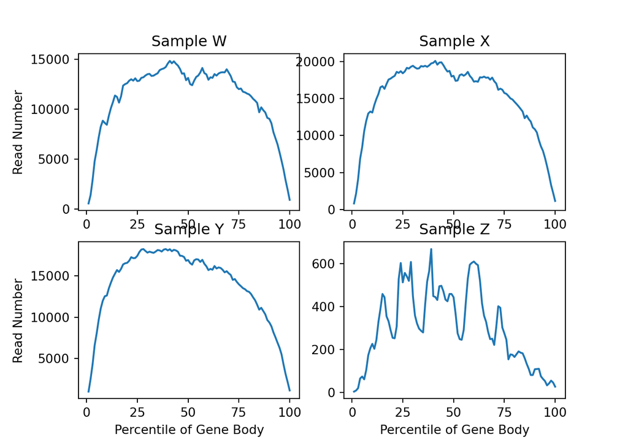

```python
# load in our data
path = './Q2/geneBodyCoverage.geneBodyCoverage.txt'
file = open(path, 'r')
lines = file.readlines()

# transforming data to pandas df
percentile, W, Y, Z, X = lines

percentile = percentile.split("\t")
X = X.split("\t")
Y = Y.split("\t")
Z = Z.split("\t")
W = W.split("\t")

data = np.array([percentile, W, X, Y, Z])
data = data.transpose()

df = pd.DataFrame(data=data, columns=["Percentile", "W", "X", "Y", "Z"])
df = df.drop(df.index[0])
df = df.astype(float)

# Making plots
fig, axs = plt.subplots(2, 2)
axs[0, 0].plot(df["Percentile"], df["W"])
axs[0, 0].set_title('Sample W')
axs[0, 0].set_ylabel("Read Number")
axs[0, 1].plot(df["Percentile"], df["X"])
axs[0, 1].set_title('Sample X')
axs[1, 0].plot(df["Percentile"], df["Y"])
axs[1, 0].set_title('Sample Y')
axs[1, 0].set_xlabel("Percentile of Gene Body")
axs[1, 0].set_ylabel("Read Number")
axs[1, 1].plot(df["Percentile"], df["Z"])
axs[1, 1].set_title('Sample Z')
axs[1, 1].set_xlabel("Percentile of Gene Body")
```

Based on the python script and graphs, I once again conclude thaty sample Z is the worst sample (due to irregularity - bouncing around).

### Problem 4: RNA-seq quantification

Transcript quantification plays an important role in the analysis of RNA-seq data. A large number of tools have been developed to quantify expression at the transcript level. RSEM (Bo Li et al, BMC Bioinformatics 2011) is a software package for estimating gene and isoform expression levels from single-end or paired-end RNA-Seq data, it can perform the alignment step with three different aligners: bowtie, bowtie2, or STAR. Salmon (Rob Patro et al, Nature Methods 2017) is an ultra-fast alignment-free method which also can correct for GC-bias.

**Please run STAR+RSEM and Salmon on one good quality sample from problem 2 and 3 to get FPKM and TPM. Identify the transcript and gene with the highest expression in this library from the Salmon output.**

```
data: /2021/HW1/raw_data2/
module: STAR/2.6.0c-fasrc01, rsem/1.2.29-fasrc03, salmon/0.12.0-fasrc01
index: /2021/HW1/index/salmon_hg38_index,/2021/HW1/index/rsem_hg38_index
```

```bash
# load salmon module
module load salmon/0.12.0-fasrc01

# salmon command
salmon quant -i /n/stat115/2021/HW1/index/salmon_hg38_index -l A -r /n/stat115/2021/HW1/raw_data2/fastqFile/runX.fastq -p 16 -o ${HOME}

# transfer to local directory (on local terminal)
scp stat215u2107@login.rc.fas.harvard.edu:quant.sf "/Users/nahmed/Desktop/Local Spring 2021/STAT215/Coursework/HW1/Q4"

# get gene with largest TPM (highest TPM)
sort -k4n quant.sf | tail -10

# restart session to do RSEM
exit()

# transitioning from the login node to the computing node
srun --nodes=1 --ntasks-per-node=1 --mem=64G --cpus-per-task=8 --time=06:00:00 --pty bash -i

# go to home directory
cd ${HOME}

# load STAR module
module load STAR/2.6.0c-fasrc01

# STAR component
STAR --genomeDir /n/stat115/2021/HW1/index/star_hg38_index --readFilesIn /n/stat115/2021/HW1/raw_data2/fastqFile/runX.fastq --runThreadN 16 --quantMode TranscriptomeSAM --outSAMtype BAM SortedByCoordinate

# load RSEM
module load rsem

# RSEM
rsem-calculate-expression --no-bam-output --time --bam -p 16 Aligned.toTranscriptome.out.bam /n/stat115/2021/HW1/index/rsem_hg38_index/rsem_index rsemOutput

# get RSEM time (for #5)
cat rsemOutput.time

# transfer to local directory (on local terminal)
scp stat215u2107@login.rc.fas.harvard.edu:rsemOutput.isoforms.results "/Users/nahmed/Desktop/Local Spring 2021/STAT215/Coursework/HW1/Q4"

# get RSEM results (highest TPM)
sort -k6n rsemOutput.isoforms.results| tail -10
```

### Problem 5: Speed Comparison

**Report the relative speed of STAR+RSEM and Salmon for the analyses of the sample. Comment on your results based on the lecture material.**

For Salmon, I look at the log and observed the start (2021-02-07 22:35:57.431) and end time (2021-02-07 22:37:12.266). It took about 75 seconds. For STAR+RSEM method, RSEM took 788 seconds (use –time option) (this time doesn’t account for STAR making the BAM file which took a couple minutes). From this analysis, it seems Salmon is faster which make sense since RSEM uses alignment which slows it down whereas Salmon doesn’t use alignment - Salmon uses a newer algorithm that is much quicker!

### Problem 6:

**Plot the relationship between effective length, normalized read counts, TPM, and FPKM for this sample from the RSEM and Salmon output. Comment on the relative utility of each metric when analyzing gene expression data.**

```r
library(dplyr)
```

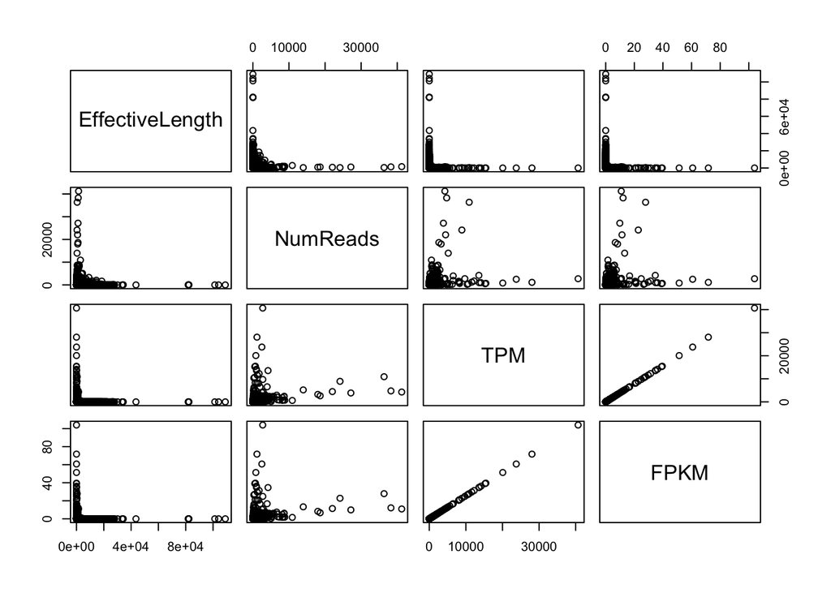

```r
# import the data
salmon = read.delim("./Q4/salmon.txt", header = TRUE, sep = "\t", dec = ".")
rsem = read.delim("./Q4/rsem.txt", header = TRUE, sep = "\t", dec = ".")

# Calculating FPKM for Salmon (divide NumReads by read counts by the “per million” scaling factor (PMSF) and effective length of gene)
PMSF = sum(salmon$NumReads)/1000000
salmon$FPKM = salmon$NumReads/(PMSF*salmon$EffectiveLength)

# edit df to be columns of interests
salmon = salmon %>% select(EffectiveLength, NumReads, TPM, FPKM)
rsem = rsem %>% select(effective_length, expected_count, TPM, FPKM)

pairs(salmon)
```

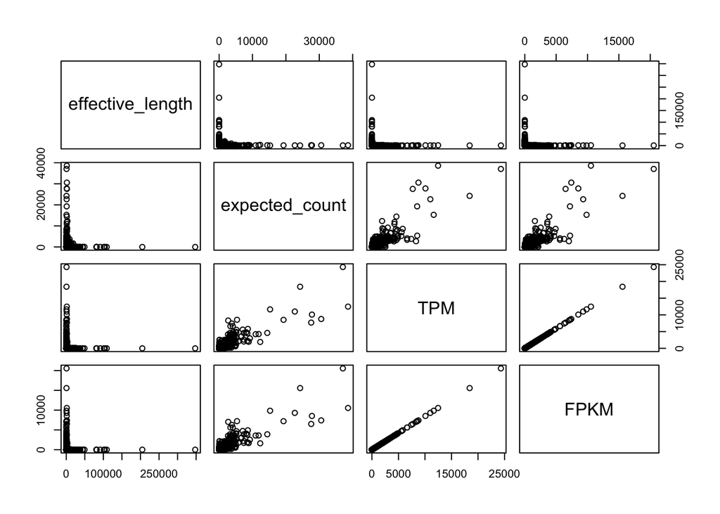

```r
pairs(rsem)
```

```r
cor(salmon)
```

```
##                 EffectiveLength   NumReads         TPM       FPKM
## EffectiveLength      1.00000000 0.02814144 -0.01616099 -0.0161610
## NumReads             0.02814144 1.00000000  0.31634730  0.3163469
## TPM                 -0.01616099 0.31634730  1.00000000  1.0000000
## FPKM                -0.01616100 0.31634687  1.00000000  1.0000000
```

```r
cor(rsem)
```

```
##                  effective_length expected_count         TPM         FPKM
## effective_length      1.000000000     0.02549477 -0.00718152 -0.007181519
## expected_count        0.025494769     1.00000000  0.87135149  0.871351494
## TPM                  -0.007181520     0.87135149  1.00000000  1.000000000
## FPKM                 -0.007181519     0.87135149  1.00000000  1.000000000
```

Plotting all the pairwise relationship, I observe the trends for RSEM and Salmon outputs are very similar.

Comparing TPM and FPKM, we see they are positively and highly correlated for Salmon and RSEM method (they have correlation of 1). This makes sense as both are metrics for expressing gene presence.

For Number of Reads, I saw that increasing the number of reads results in generally higher TPM and FPKM which makes sense since the formula for these metrics are positively correlated with read number. This seems to be more the case for the RSEM with a higher correlation coefficient compared to Salmon.

For Effective Length, it seems there’s not a clear pattern seeing spikes to the right and up. This could imply that TPM and FPKM is robust to the effective length (not as impacted). The relationship between Effective Length and Number of Reads is also not highly related (no clear pattern). This make senses as they seem to be fairly independent of each other. This is also demonstrated by the correlation coefficients being low.

In conclusion, TPM and FPKM are highly correlated, Number of Reads is positively related to both metrics, and Effective Length seems fairly uncorrelated.